# Biostat 203B Homework 2

Due Feb 10 @ 11:59PM

```r
knitr::opts_chunk$set(echo = TRUE, cache = TRUE, cache.lazy = FALSE)
library(tidyverse)
library(data.table)
library(lubridate)
os <- sessionInfo()$running
if (str_detect(os, "Linux")) {
  mimic_path <- "/usr/203b-data/mimic-iv"
} else if (str_detect(os, "macOS")) {
  mimic_path <- "/Users/asburysean/Documents/Box Sync/MIMIC/mimic-iv-0.4"
}
```

Use tidyverse (ggpot2, dplyr) to explore the [MIMIC-IV](https://mimic-iv.mit.edu) data introduced in [homework 1](https://ucla-biostat203b-2021winter.github.io/hw/hw1/hw1.html)

```r
system(str_c("tree -s -L 2 ", shQuote(mimic_path)), intern = TRUE)
```

```
##  [1] "/usr/203b-data/mimic-iv"
##  [2] "├── [         78]  core"
##  [3] "│   ├── [   17224843]  admissions.csv.gz"
##  [4] "│   ├── [    2884996]  patients.csv.gz"
##  [5] "│   └── [   51188147]  transfers.csv.gz"
##  [6] "├── [       4096]  hosp"
##  [7] "│   ├── [     430049]  d_hcpcs.csv.gz"
##  [8] "│   ├── [   26575586]  diagnoses_icd.csv.gz"
##  [9] "│   ├── [     723633]  d_icd_diagnoses.csv.gz"
## [10] "│   ├── [     564422]  d_icd_procedures.csv.gz"
## [11] "│   ├── [      14845]  d_labitems.csv.gz"
## [12] "│   ├── [   12913088]  drgcodes.csv.gz"
## [13] "│   ├── [  518077567]  emar.csv.gz"
## [14] "│   ├── [  479709397]  emar_detail.csv.gz"
## [15] "│   ├── [    1415469]  hcpcsevents.csv.gz"
```

[output cut: 20 more lines]

## Q1. PhysioNet credential

At this moment, you should already get credentialed on the PhysioNet. Please include a screenshot of your `Data Use Agreement for the MIMIC-IV (v0.4)`.

[figure not shown]

## Q2. `read.csv` (base R) vs `read_csv` (tidyverse) vs `fread` (data.table)

There are quite a few utilities in R for reading data files. Let us test the speed of reading a moderate sized compressed csv file, `admissions.csv.gz`, by three programs: `read.csv` in base R, `read_csv` in tidyverse, and `fread` in the popular data.table package. Is there any speed difference?

```r
## read.csv time
system.time(read.csv("/usr/203b-data/mimic-iv/core/admissions.csv.gz"))
```

```
##    user  system elapsed
##  52.328   0.523  53.055
```

```r
# read_csv time
system.time(read_csv("/usr/203b-data/mimic-iv/core/admissions.csv.gz"))
```

```
##    user  system elapsed
##   4.503   0.301   5.845
```

```r
#Fread Time
system.time(fread("/usr/203b-data/mimic-iv/core/admissions.csv.gz"))
```

```
##    user  system elapsed
##   3.021   0.194   2.199
```

```r
read_csv("/usr/203b-data/mimic-iv/core/admissions.csv.gz")
```

```
## # A tibble: 524,520 x 15
##    subject_id hadm_id admittime           dischtime
##         <dbl>   <dbl> <dttm>              <dttm>
##  1   12427812  2.16e7 2184-01-06 11:51:00 2184-01-10 11:45:00
##  2   14029832  2.21e7 2120-01-18 01:28:00 2120-01-20 16:13:00
##  3   14495017  2.25e7 2175-01-28 15:41:00 2175-01-29 16:00:00
##  4   13676048  2.39e7 2193-01-19 05:27:00 2193-01-24 18:59:00
##  5   13831972  2.78e7 2131-01-27 04:03:00 2131-01-27 05:39:00
##  6   18523038  2.54e7 2142-08-26 17:14:00 2142-08-27 10:00:00
##  7   16705931  2.06e7 2174-10-24 11:30:00 2174-10-24 18:45:00
##  8   19963742  2.50e7 2171-07-04 15:58:00 2171-07-05 13:37:00
##  9   10903424  2.26e7 2181-01-31 13:09:00 2181-01-31 13:42:00
## 10   15030422  2.20e7 2149-09-21 23:54:00 2149-09-22 03:59:00
## # … with 524,510 more rows, and 11 more variables: deathtime <dttm>,
## #   admission_type <chr>, admission_location <chr>, discharge_location <chr>,
## #   insurance <chr>, language <chr>, marital_status <chr>, ethnicity <chr>,
## #   edregtime <dttm>, edouttime <dttm>, hospital_expire_flag <dbl>
```

## Q3. ICU stays

`icustays.csv.gz` (https://mimic-iv.mit.edu/docs/datasets/icu/icustays/) contains data about Intensive Care Units (ICU) stays. Summarize following variables using appropriate numerics or graphs:

- how many unique `stay_id`?
- how many unique `subject_id`?
- length of ICU stay
- first ICU unit
- last ICU unit

```r
df <- read_csv("/usr/203b-data/mimic-iv/icu/icustays.csv.gz")
head(df)
```

```
## # A tibble: 6 x 8
##   subject_id hadm_id stay_id first_careunit last_careunit intime
##        <dbl>   <dbl>   <dbl> <chr>          <chr>         <dttm>
## 1   17823467  2.76e7  3.60e7 Coronary Care… Coronary Car… 2138-05-09 05:08:00
## 2   15772648  2.61e7  3.96e7 Trauma SICU (… Trauma SICU … 2146-06-18 18:35:00
## 3   13713711  2.58e7  3.64e7 Trauma SICU (… Trauma SICU … 2157-09-15 15:30:00
## 4   13173210  2.23e7  3.82e7 Coronary Care… Coronary Car… 2178-02-12 17:13:50
## 5   10213765  2.85e7  3.98e7 Trauma SICU (… Trauma SICU … 2113-04-10 14:11:00
## 6   17530304  2.18e7  3.58e7 Trauma SICU (… Trauma SICU … 2129-03-21 07:09:00
## # … with 2 more variables: outtime <dttm>, los <dbl>
```

```r
unique(df[c("stay_id")])
```

```
## # A tibble: 69,619 x 1
##     stay_id
##       <dbl>
##  1 35964304
##  2 39637383
##  3 36363748
##  4 38210858
##  5 39765853
##  6 35848367
##  7 37788595
##  8 39262919
##  9 36989766
## 10 34766377
## # … with 69,609 more rows
```

```r
## Number of unique stay id's
n_distinct(df[c("stay_id")])
```

```
## [1] 69619
```

```r
unique(df[c("subject_id")])
```

```
## # A tibble: 50,048 x 1
##    subject_id
##         <dbl>
##  1   17823467
##  2   15772648
##  3   13713711
##  4   13173210
##  5   10213765
##  6   17530304
##  7   10297774
##  8   16766597
##  9   17684317
## 10   15693895
## # … with 50,038 more rows
```

```r
## Number of unique subect id's
n_distinct(df[c("subject_id")])
```

```
## [1] 50048
```

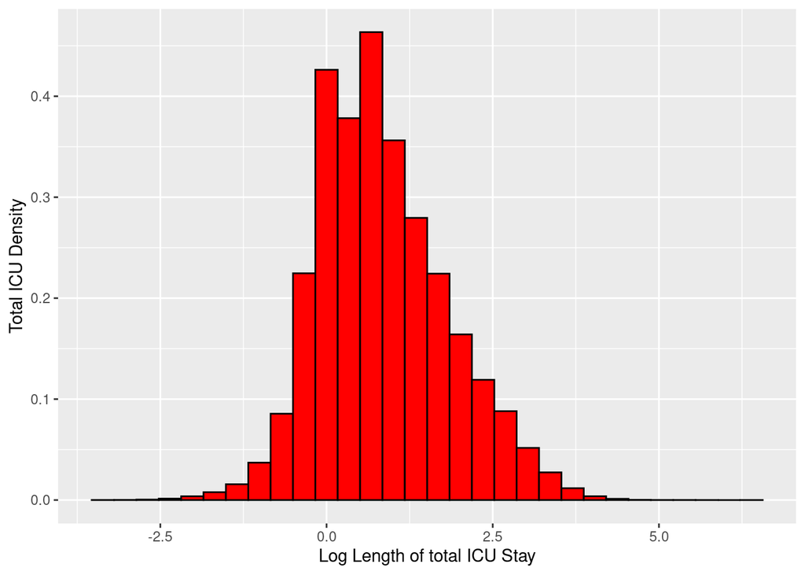

```r
## Length of ICU stay
ggplot(data = df, mapping = aes(x = log(los))) +
  geom_histogram(aes(y=..density..), color = 'black', fill = 'red', bins = 30) +
  xlab("Log Length of total ICU Stay") + ylab("Total ICU Density")
```

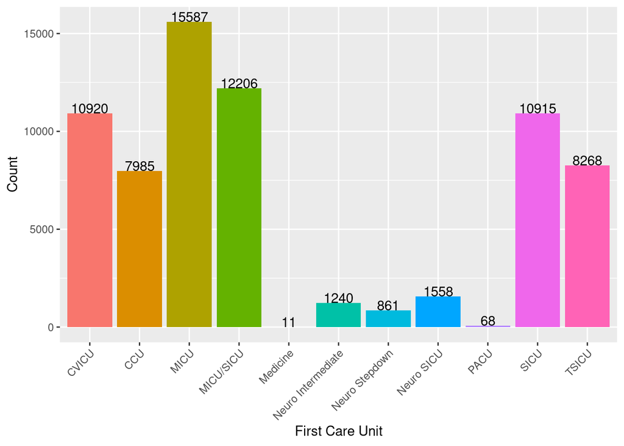

```r
## First ICU unit
ggplot(data = df,mapping = aes(x = factor(first_careunit), y = stat(count),
  fill = first_careunit))+ geom_bar(stat = "count")  +
  geom_text(stat = 'count', aes(label=..count..), vjust=0) +
  theme(axis.text.x = element_text(angle = 45, hjust = 1)) +
  scale_x_discrete(labels = c('CVICU','CCU','MICU', 'MICU/SICU', 'Medicine',
'Neuro Intermediate', 'Neuro Stepdown', 'Neuro SICU', 'PACU','SICU','TSICU')) +
  guides(fill=FALSE) + xlab("First Care Unit") + ylab("Count")
```

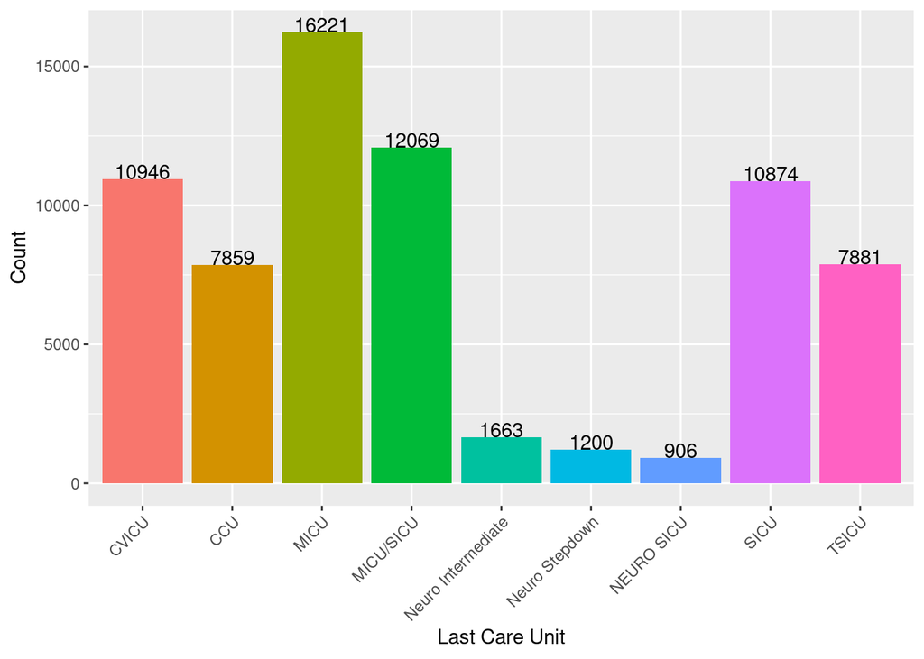

```r
## Last ICU Unit
ggplot(data = df,mapping = aes(x = factor(last_careunit),
  fill = last_careunit)) + geom_bar(stat = "count") +
  geom_text(stat = 'count', aes(label=..count..), vjust=0) +
  theme(axis.text.x = element_text(angle = 45, hjust = 1)) +
  scale_x_discrete(labels = c('CVICU', 'CCU','MICU','MICU/SICU',
  'Neuro Intermediate', 'Neuro Stepdown', 'NEURO SICU', 'SICU', 'TSICU')) +
  guides(fill=FALSE) + xlab("Last Care Unit") + ylab("Count")
```

## Q4. `admission` data

Note it is possible that one patient (uniquely identified by the `subject_id`) is admitted into hospital multiple times. When summarizing some demographic information, it makes sense to summarize based on unique patients.

```r
dfadd <- read_csv("/usr/203b-data/mimic-iv/core/admissions.csv.gz")
head(dfadd)
```

```
## # A tibble: 6 x 15
##   subject_id hadm_id admittime           dischtime           deathtime
##        <dbl>   <dbl> <dttm>              <dttm>              <dttm>
## 1   12427812  2.16e7 2184-01-06 11:51:00 2184-01-10 11:45:00 NA
## 2   14029832  2.21e7 2120-01-18 01:28:00 2120-01-20 16:13:00 NA
## 3   14495017  2.25e7 2175-01-28 15:41:00 2175-01-29 16:00:00 NA
## 4   13676048  2.39e7 2193-01-19 05:27:00 2193-01-24 18:59:00 NA
## 5   13831972  2.78e7 2131-01-27 04:03:00 2131-01-27 05:39:00 NA
## 6   18523038  2.54e7 2142-08-26 17:14:00 2142-08-27 10:00:00 NA
## # … with 10 more variables: admission_type <chr>, admission_location <chr>,
## #   discharge_location <chr>, insurance <chr>, language <chr>,
## #   marital_status <chr>, ethnicity <chr>, edregtime <dttm>, edouttime <dttm>,
## #   hospital_expire_flag <dbl>
```

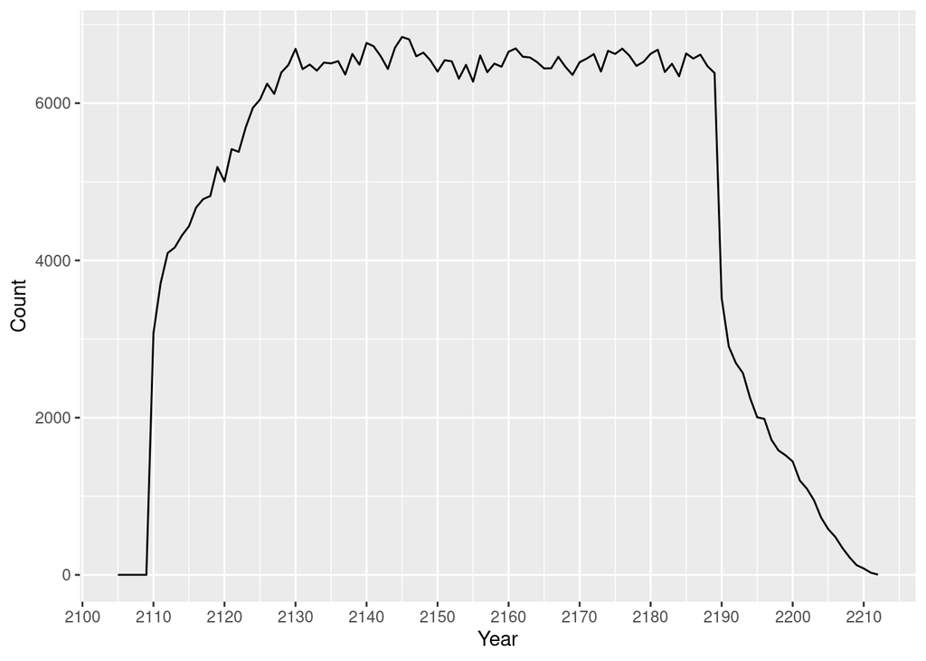

```r
## Admission year ##
ggplot(data = dfadd,mapping = aes(x = year(admittime), y = stat(count))) +
  geom_freqpoly(stat = "count") + scale_x_continuous(n.breaks = 15) +
  xlab("Year") + ylab("Count")
```

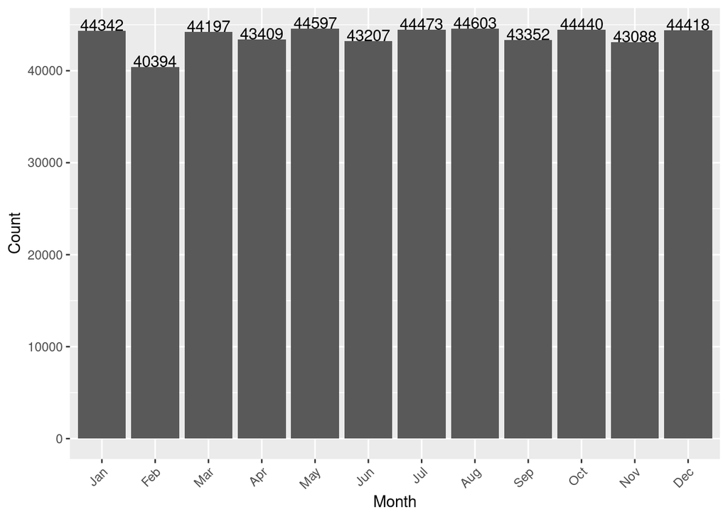

```r
## Admission Month ##
ggplot(data = dfadd,mapping = aes(x = month(admittime, label = TRUE),
                                  y = stat(count)))+ geom_bar() +
  geom_text(stat = 'count', aes(label=..count..), vjust=0) +
  theme(axis.text.x = element_text(angle = 45, hjust = 1)) +
  xlab("Month") + ylab("Count")
```

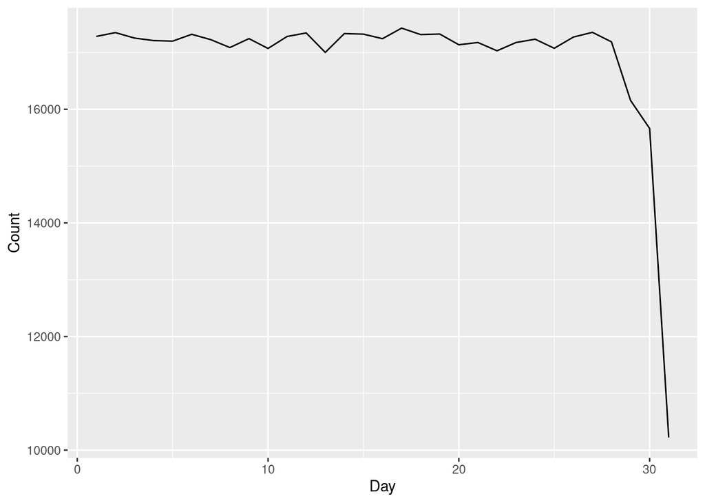

```r
## Admission Month Day ##
ggplot(data = dfadd,mapping = aes(x = mday(admittime), y = stat(count),
                                  axis(1, seq(1,30,1)))) +
  geom_freqpoly(stat = "count") + scale_x_continuous(n.breaks = 30) +
  scale_x_continuous(limits = c(1, 31)) + xlab("Day") + ylab("Count")
```

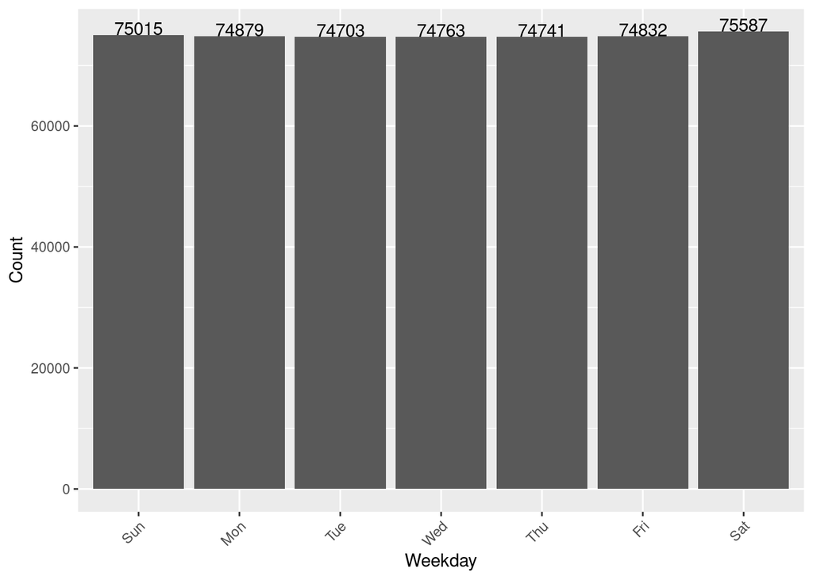

```r
##Admission Week Day ##
ggplot(data = dfadd,mapping = aes(x = wday(admittime, label = TRUE) ,
                                  y = stat(count)))+ geom_bar() +
  geom_text(stat = 'count', aes(label=..count..), vjust=0) +
  theme(axis.text.x = element_text(angle = 45, hjust = 1)) +
  xlab("Weekday") + ylab("Count")
```

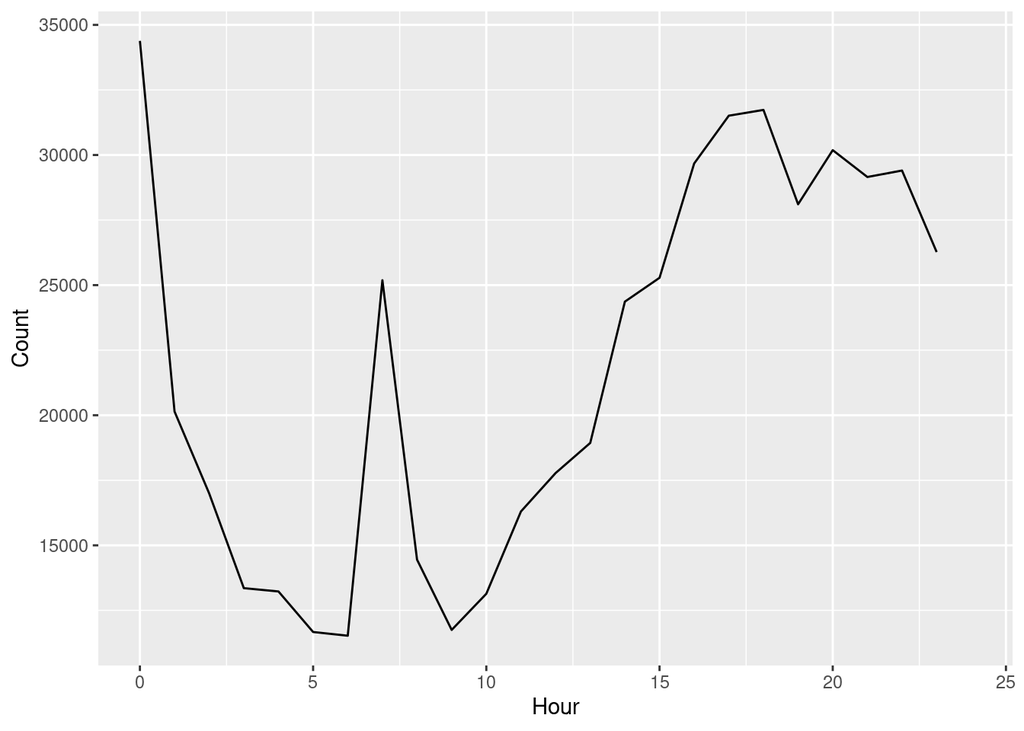

```r
## Admission Hour ##
ggplot(data = dfadd,mapping = aes(x = hour(admittime), y = stat(count))) +
  geom_freqpoly(stat = "count") + scale_x_continuous(n.breaks = 24) +
  scale_x_continuous(limits = c(0, 24)) + xlab("Hour") + ylab("Count")
```

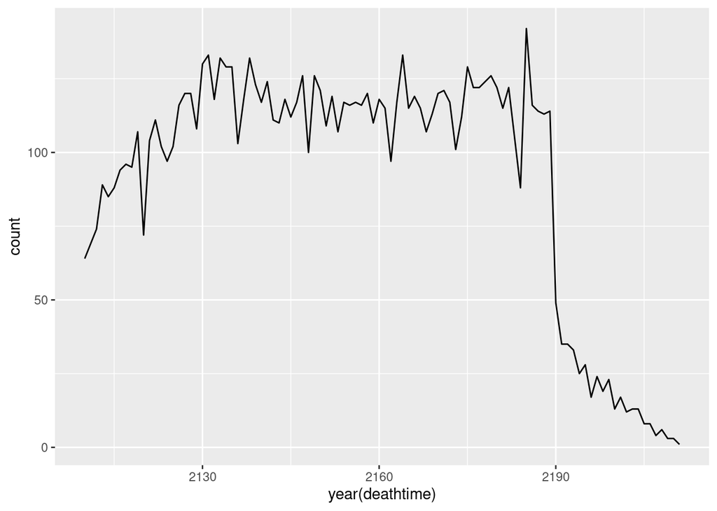

```r
## Death per Year ##
ggplot(data = dfadd,mapping = aes(x = year(deathtime), y = stat(count))) +
  geom_freqpoly(stat = "count")
```

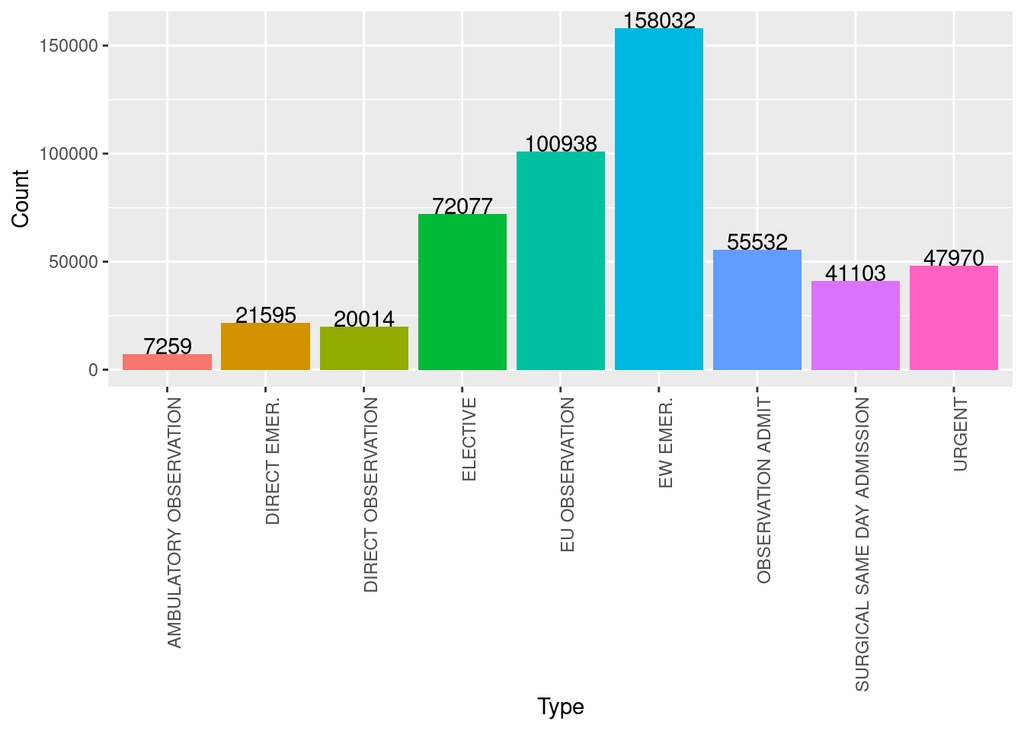

```r
##admission type##
ggplot(data = dfadd,mapping = aes(x = factor(admission_type), y = stat(count),
  fill = admission_type))+ geom_bar(stat = "count")  +
  geom_text(stat = 'count', aes(label=..count..), vjust=0) +
  theme(axis.text.x = element_text(angle = 90, hjust = 1)) +
  guides(fill=FALSE) + xlab("Type") + ylab("Count")
```

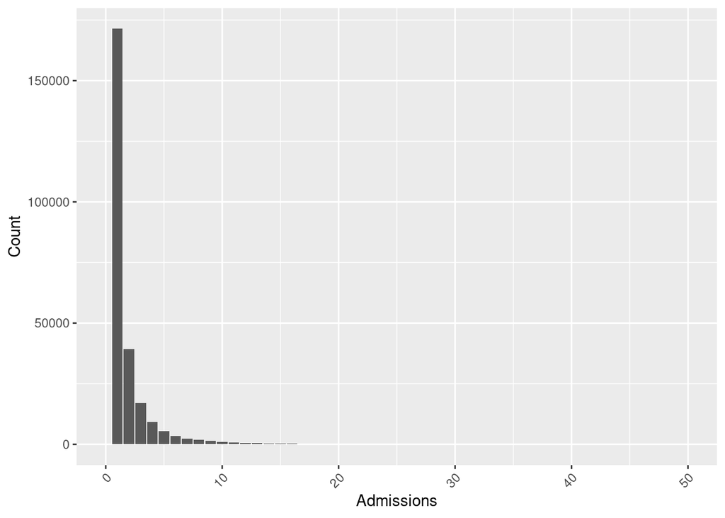

```r
##number of admissions per patient minus outliers##
df <- dfadd %>% count(subject_id)
ggplot(data = df,mapping = aes(x = n, y = stat(count)), xlim=c(0,50)) +
  geom_bar() + theme(axis.text.x = element_text(angle = 45, hjust = 1)) +
  scale_x_continuous(limits = c(0, 50)) + xlab("Admissions") + ylab("Count")
```

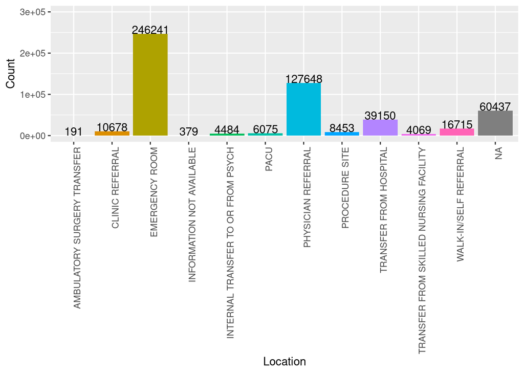

```r
##admission location##
ggplot(data = dfadd,mapping = aes(x = factor(admission_location),
                                  y = stat(count),fill = admission_location)) +
  geom_bar(stat = "count")  +
  geom_text(stat = 'count', aes(label=..count..), vjust=0) +
  theme(axis.text.x = element_text(angle = 90, hjust = 1)) +
  scale_y_continuous(limits = c(0, 300000)) + guides(fill=FALSE) +
  xlab("Location") + ylab("Count")
```

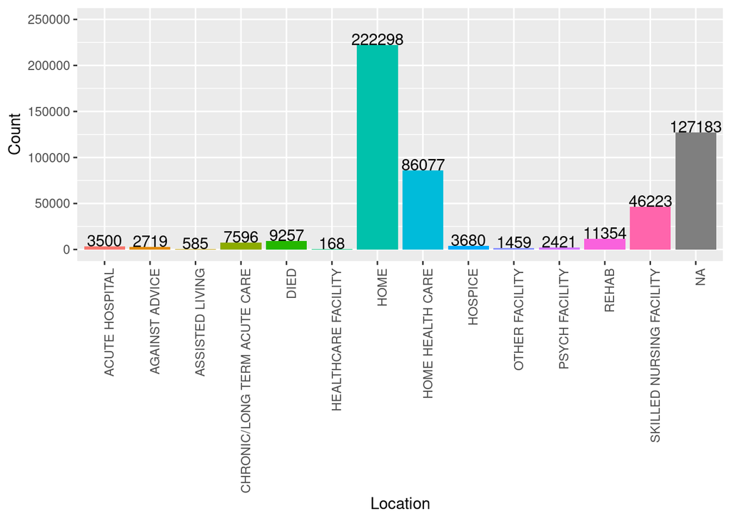

```r
##discharge location##
ggplot(data = dfadd,mapping = aes(x = factor(discharge_location),
                                  y = stat(count),fill = discharge_location)) +
  geom_bar(stat = "count")  +
  geom_text(stat = 'count', aes(label=..count..), vjust=0) +
  theme(axis.text.x = element_text(angle = 90, hjust = 1)) +
  guides(fill=FALSE) +  scale_y_continuous(limits = c(0, 250000)) +
  xlab("Location") + ylab("Count")
```

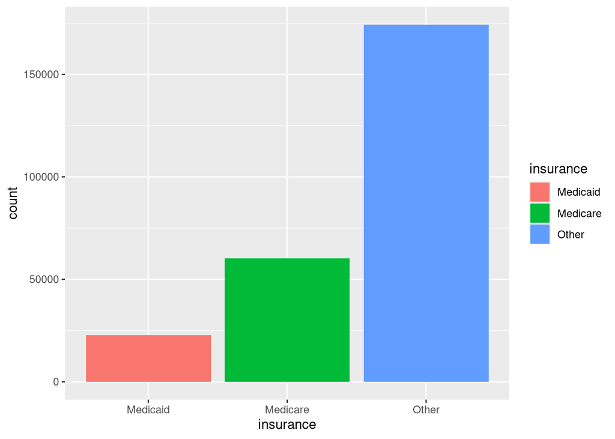

```r
##insurance##
ggplot(dfadd %>%
         distinct(subject_id, .keep_all = TRUE)) +
  geom_bar(mapping = aes(x = insurance, y = stat(count), fill = insurance))
```

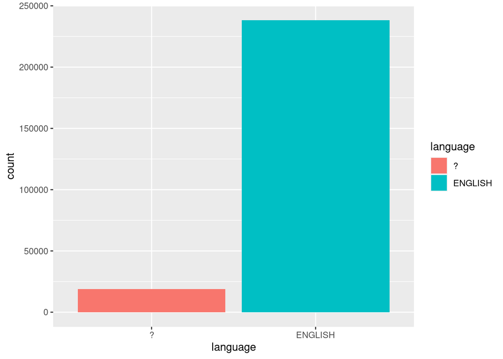

```r
##language##
ggplot(dfadd %>%
         distinct(subject_id, .keep_all = TRUE)) +
  geom_bar(mapping = aes(x = language, y = stat(count), fill = language))
```

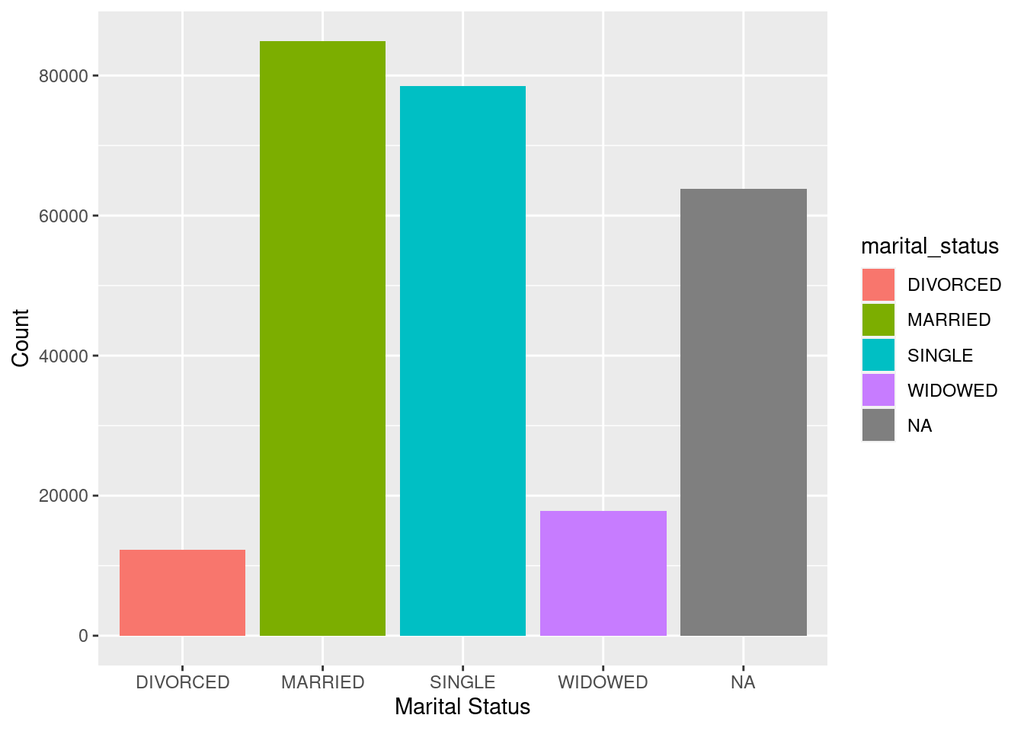

```r
##marital status##
ggplot(dfadd %>%
         distinct(subject_id, .keep_all = TRUE)) +
  geom_bar(mapping = aes(x = marital_status, y = stat(count),
                         fill = marital_status)) + xlab("Marital Status") +
  ylab("Count")
```

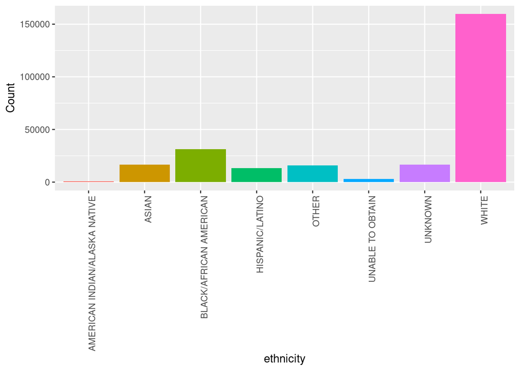

```r
##ethnicity##
ggplot(dfadd %>%
         distinct(subject_id, .keep_all = TRUE)) +
  geom_bar(mapping = aes(x = ethnicity, y = stat(count),
                         fill = ethnicity)) +
  theme(axis.text.x = element_text(angle = 90, hjust = 1)) +
  guides(fill=FALSE) + xlab("ethnicity") + ylab("Count")
```

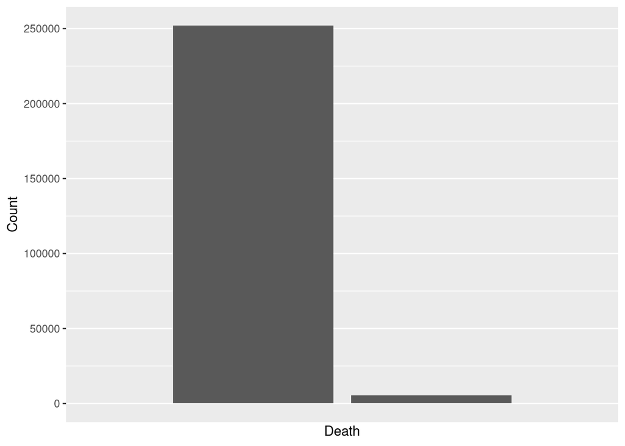

```r
##Death##
ggplot(dfadd %>%
         distinct(subject_id, .keep_all = TRUE)) +
  geom_bar(mapping = aes(x = hospital_expire_flag, y = stat(count),
                         fill = hospital_expire_flag)) +
  theme(axis.text.x = element_text(angle = 90, hjust = 1)) +
  guides(fill=FALSE) + xlab("Death") + ylab("Count") +
  scale_x_discrete(labels = c('Death', 'No death'))
```

## Q5. `patient` data

Explore `patients.csv.gz` (https://mimic-iv.mit.edu/docs/datasets/core/patients/) and summarize following variables using appropriate numerics and graphs:

**Solution** : - `gender` More females then males - `anchor_age` (explain pattern you see) A large amount of people at zero, I am guessing this is births and most people tend to be between 18 and 90 with a large peak right past 90, porbably deaths.

```r
dfp <- read_csv("/usr/203b-data/mimic-iv/core/patients.csv.gz")
head(dfp)
```

```
## # A tibble: 6 x 6
##   subject_id gender anchor_age anchor_year anchor_year_group dod
##        <dbl> <chr>       <dbl>       <dbl> <chr>             <lgl>
## 1   10002723 F               0        2128 2017 - 2019       NA
## 2   10003939 M               0        2184 2008 - 2010       NA
## 3   10004222 M               0        2161 2014 - 2016       NA
## 4   10005325 F               0        2154 2011 - 2013       NA
## 5   10007338 F               0        2153 2017 - 2019       NA
## 6   10008101 M               0        2142 2008 - 2010       NA
```

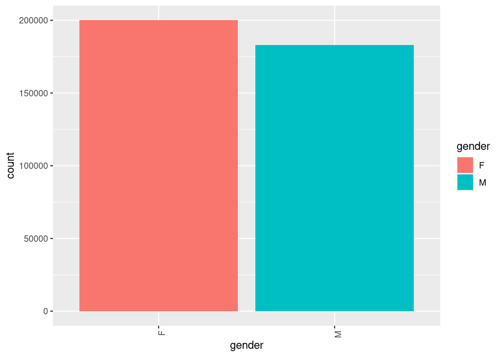

```r
##Gender##
ggplot(dfp %>%
         distinct(subject_id, .keep_all = TRUE)) +
  geom_bar(mapping = aes(x = gender, y = stat(count),
                         fill = gender)) +
  theme(axis.text.x = element_text(angle = 90, hjust = 1))
```

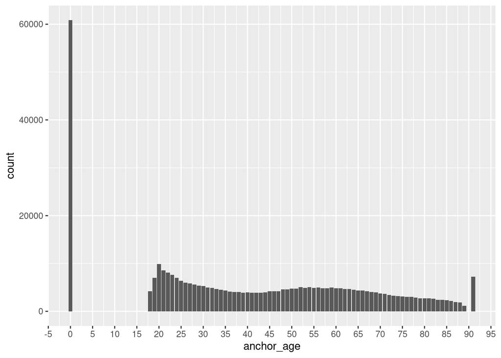

```r
##anchor_age##
ggplot(dfp %>%
         distinct(subject_id, .keep_all = TRUE)) +
  geom_bar(mapping = aes(x = anchor_age, y = stat(count), fill = anchor_age)) +
   scale_x_continuous(n.breaks = 24)
```

## Q6. Lab results

`labevents.csv.gz` (https://mimic-iv.mit.edu/docs/datasets/hosp/labevents/) contains all laboratory measurements for patients.

We are interested in the lab measurements of creatinine (50912), potassium (50971), sodium (50983), chloride (50902), bicarbonate (50882), hematocrit (51221), white blood cell count (51301), glucose (50931), magnesium (50960), calcium (50893), and lactate (50813). Find the `itemid`s of these lab measurements from `d_labitems.csv.gz` and retrieve a subset of `labevents.csv.gz` only containing these items.

```r
#This is what I tried the first time but it keeps crashing.
#Therefore it doesnt run. I will try and use Dr.Zhou's filtered data.
# if(!file.exists("labevents_icustays.csv.gz")){
#  system.time(labevents_tble <-
#         fread(str_c(mimic_path, "/hosp/labevents.csv.gz"),
#            select = c("subject_id", "hadm_id", "itemid",
#                  "charttime", "valuenum"),
#            nThread = 4))
#  labevents_tble %>%
#   semi_join(icustays_tble, by = c("subject_id", "hadm_id")) %>%
#   fwrite("labevents_icustays.csv.gz", nThread = 4)
# }

#Dr zhos method we can use for the future use, using git commands.
# zcat < /usr/203b-data/mimic-iv/hosp/labevents.csv.gz |
#awk -F, '{OFS = ","} {if ($5 == 50912 || $5 == 50971 || $5 == 50983 ||
#$5 == 50902 || $5 == 50882 || $5 == 51221 || $5 == 51301 || $5 == 50931 ||
#$5 == 50960 || $5 == 50893 || $5 == 50813) print $2, $3, $5, $6, $9}' | gzip > #labevents_filtered_itemid.csv.gz

icustays_tble <- read_csv("/usr/203b-data/mimic-iv/icu/icustays.csv.gz")
system.time(labevents_tble <- fread("/usr/203b-data/mimic-iv-derived-data/labevents_filtered_itemid.csv.gz",
header = FALSE, col.names = c("subject_id", "hadm_id", "itemid", "charttime",
                              "valuenum"),
                               nThread = 4) %>%
                               as_tibble()%>%
                               mutate_at(c("subject_id", "hadm_id", "itemid"),
                               as.numeric) %>%
                               mutate(charttime = ymd_hms(charttime)) %>%
                               print(width = Inf))
```

```
## # A tibble: 30,773,355 x 5
##    subject_id  hadm_id itemid charttime           valuenum
##         <dbl>    <dbl>  <dbl> <dttm>                 <dbl>
##  1   12455438 24471620  51301 2151-05-06 04:45:00     16.3
##  2   12455438 24471620  50882 2151-05-06 04:45:00     23
##  3   12455438 24471620  50893 2151-05-06 04:45:00      8.8
##  4   12455438 24471620  50902 2151-05-06 04:45:00    106
##  5   12455438 24471620  50912 2151-05-06 04:45:00      0.7
##  6   12455438 24471620  50960 2151-05-06 04:45:00      2.4
##  7   12455438 24471620  50882 2151-05-06 17:16:00     23
##  8   12455438 24471620  50893 2151-05-06 17:16:00      8.9
##  9   12455438 24471620  50902 2151-05-06 17:16:00    106
## 10   12455438 24471620  50912 2151-05-06 17:16:00      0.8
## # … with 30,773,345 more rows
```

```
##    user  system elapsed
##  73.160  12.479  53.404
```

```r
#Just a trial look around
# labitem <- 'Creatinine'
# creatinine_items <- labitems_tbl %>%
#   filter(str_detect(label, regex(labitem, ignore_case = T))) %>%
#   print(width = Inf)

labitems_tbl <- read_csv(str_c(mimic_path, "/hosp/d_labitems.csv.gz")) %>%
  print(width = Inf)
```

```
## # A tibble: 1,625 x 5
##    itemid label                     fluid            category   loinc_code
##     <dbl> <chr>                     <chr>            <chr>      <chr>
##  1  51898 <NA>                      Other Body Fluid Chemistry  <NA>
##  2  51532 11-Deoxycorticosterone    Blood            Chemistry  <NA>
##  3  51952 17-Hydroxycorticosteroids Urine            Chemistry  <NA>
##  4  51953 17-Ketosteroids, Urine    Urine            Chemistry  <NA>
##  5  52063 24 Hr                     Blood            Hematology <NA>
##  6  51066 24 hr Calcium             Urine            Chemistry  <NA>
##  7  51067 24 hr Creatinine          Urine            Chemistry  <NA>
##  8  51068 24 hr Protein             Urine            Chemistry  <NA>
##  9  50853 25-OH Vitamin D           Blood            Chemistry  <NA>
## 10  51533 3t                        Blood            Chemistry  <NA>
## # … with 1,615 more rows
```

```r
labitems <- c("creatinine", "potassium", "sodium", "chloride", "bicarbonate",
              "hematocrit", "white blood cell", "glucose", "magnesium",
              "calcium", "lactate")
itemids <- rep(0, length(labitems))
i <- 1
for (labitem in labitems) {
  print(str_interp("search for ${labitem}"))
  itemid_list <- labitems_tbl %>%
    filter(str_detect(label, regex(labitem, ignore_case = T))) %>%
    .$itemid
  itemid <- labevents_tble %>%
    filter(itemid %in% itemid_list) %>%
    count(itemid) %>%
    arrange(desc(n)) %>%
    slice(1) %>%
    .$itemid
  itemids[i] <- itemid
  i <- i + 1
}
```

```
## [1] "search for creatinine"
## [1] "search for potassium"
## [1] "search for sodium"
## [1] "search for chloride"
## [1] "search for bicarbonate"
## [1] "search for hematocrit"
## [1] "search for white blood cell"
## [1] "search for glucose"
## [1] "search for magnesium"
## [1] "search for calcium"
## [1] "search for lactate"
```

Read in the lab item dictionary

```r
labitem_itemid <- tibble(itemid = itemids, labitem = labitems) %>% print(width = Inf)
```

```
## # A tibble: 11 x 2
##    itemid labitem
##     <dbl> <chr>
##  1  50912 creatinine
##  2  50971 potassium
##  3  50983 sodium
##  4  50902 chloride
##  5  50882 bicarbonate
##  6  51221 hematocrit
##  7  51301 white blood cell
##  8  50931 glucose
##  9  50960 magnesium
## 10  50893 calcium
## 11  50813 lactate
```

## Q7. Vitals from chartered events

We are interested in the vitals for ICU patients: heart rate, mean and systolic blood pressure (invasive and noninvasive measurements combined), body temperature, SpO2, and respiratory rate. Find the `itemid`s of these vitals from `d_items.csv.gz` and retrieve a subset of `chartevents.csv.gz` only containing these items.

`chartevents.csv.gz` (https://mimic-iv.mit.edu/docs/datasets/icu/chartevents/) contains all the charted data available for a patient. During their ICU stay, the primary repository of a patient’s information is their electronic chart. The `itemid` variable indicates a single measurement type in the database. The `value` variable is the value measured for `itemid`.

`d_items.csv.gz` (https://mimic-iv.mit.edu/docs/datasets/icu/d_items/) is the dictionary for the `itemid` in `chartevents.csv.gz`.

```r
#I couldn't open with this code
#fread(str_c(mimic_path, "/icu/chartevents.csv.gz"),
#            select = c("subject_id", "hadm_id", "itemid",
#                  "charttime", "valuenum"),
#            nThread = 4))


#command for th way the prof pulled out the data set we can use for future
#useage, since nothing else worked
# zcat < /usr/203b-data/mimic-iv/icu/chartevents.csv.gz |
#awk -F, '{OFS = ","} {if ($6 == 220045 || $6 == 220050
#|| $6 == 220052 || $6 == 220179 || $6 == 220181 || $6 == 220210
#|| $6 == 223761 || $6 == 229862) print $1, $2, $3, $4, $6, $8}' | gzip > chartevents_filtered_itemid.csv.gz


system.time(chartevents_tble <- fread("/usr/203b-data/mimic-iv-derived-data/chartevents_filtered_itemid.csv.gz",
       header = FALSE,
       col.names = c("subject_id",
                     "hadm_id",
                     "stay_id",
                     "charttime",
                     "itemid",
                     "valuenum"),
       nThread = 4) %>%
       as_tibble()%>%
       mutate_at(c("subject_id", "hadm_id", "stay_id", "itemid"), as.numeric) %>%
       mutate(charttime = ymd_hms(charttime)) %>%
       print(width = Inf))
```

```
## # A tibble: 30,095,996 x 6
##    subject_id  hadm_id  stay_id charttime           itemid valuenum
##         <dbl>    <dbl>    <dbl> <dttm>               <dbl>    <dbl>
##  1   10003700 28623837 35053963 2165-04-24 05:28:00 220179    152
##  2   10003700 28623837 35053963 2165-04-24 05:28:00 220181    110
##  3   10003700 28623837 35053963 2165-04-24 05:30:00 220045     65
##  4   10003700 28623837 35053963 2165-04-24 05:30:00 220210     14
##  5   10003700 28623837 35053963 2165-04-24 05:38:00 223761     97.6
##  6   10003700 28623837 35053963 2165-04-24 06:00:00 220045     56
##  7   10003700 28623837 35053963 2165-04-24 06:00:00 220179    126
##  8   10003700 28623837 35053963 2165-04-24 06:00:00 220181     88
##  9   10003700 28623837 35053963 2165-04-24 06:00:00 220210     14
## 10   10003700 28623837 35053963 2165-04-24 06:09:00 220045     55
## # … with 30,095,986 more rows
```

```
##    user  system elapsed
##  62.530  10.719  42.219
```

```r
#Find the ids in the data file, didnt notice spo2 data
unique(chartevents_tble$itemid)
```

```
## [1] 220179 220181 220045 220210 223761 220050 220052
```

```r
d_itemlbl <- read_csv(str_c(mimic_path, "/icu/d_items.csv.gz")) %>%
  print(width = Inf)
```

```
## # A tibble: 3,835 x 9
##    itemid label                                abbreviation       linksto
##     <dbl> <chr>                                <chr>              <chr>
##  1 220003 ICU Admission date                   ICU Admission date datetimeevents
##  2 220045 Heart Rate                           HR                 chartevents
##  3 220046 Heart rate Alarm - High              HR Alarm - High    chartevents
##  4 220047 Heart Rate Alarm - Low               HR Alarm - Low     chartevents
##  5 220048 Heart Rhythm                         Heart Rhythm       chartevents
##  6 220050 Arterial Blood Pressure systolic     ABPs               chartevents
##  7 220051 Arterial Blood Pressure diastolic    ABPd               chartevents
##  8 220052 Arterial Blood Pressure mean         ABPm               chartevents
##  9 220056 Arterial Blood Pressure Alarm - Low  ABP Alarm - Low    chartevents
## 10 220058 Arterial Blood Pressure Alarm - High ABP Alarm - High   chartevents
##    category            unitname param_type    lownormalvalue highnormalvalue
##    <chr>               <chr>    <chr>                  <dbl>           <dbl>
##  1 ADT                 <NA>     Date and time             NA              NA
##  2 Routine Vital Signs bpm      Numeric                   NA              NA
##  3 Alarms              bpm      Numeric                   NA              NA
##  4 Alarms              bpm      Numeric                   NA              NA
##  5 Routine Vital Signs <NA>     Text                      NA              NA
##  6 Routine Vital Signs mmHg     Numeric                   90             140
##  7 Routine Vital Signs mmHg     Numeric                   60              90
##  8 Routine Vital Signs mmHg     Numeric                   NA              NA
##  9 Alarms              mmHg     Numeric                   NA              NA
## 10 Alarms              mmHg     Numeric                   NA              NA
## # … with 3,825 more rows
```

```r
#from his data set I dont get anything with spo2 data,
#I only get 7 unique variables and it seems like there should be 8 but
#its not pulling the 8th.
d_itemlbl[d_itemlbl$itemid == 223761,]
```

```
## # A tibble: 1 x 9
##   itemid label abbreviation linksto category unitname param_type lownormalvalue
##    <dbl> <chr> <chr>        <chr>   <chr>    <chr>    <chr>               <dbl>
## 1 223761 Temp… Temperature… charte… Routine… °F       Numeric                NA
## # … with 1 more variable: highnormalvalue <dbl>
```

```r
d_items <- c("heart rate", "Arterial Blood Pressure systolic",
             "Arterial Blood Pressure mean",
             "Non Invasive Blood Pressure systolic",
             "Non Invasive Blood Pressure mean", "Temperature Fahrenheit",
             "Respiratory rate")
itemids <- rep(0, length(d_items))
i <- 1
for (item in d_items) {
  print(str_interp("search for ${item}"))
  itemid_list <- d_itemlbl %>%
    filter(str_detect(label, regex(item, ignore_case = T))) %>%
    .$itemid
  itemid <- chartevents_tble %>%
    filter(itemid %in% itemid_list) %>%
    count(itemid) %>%
    arrange(desc(n)) %>%
    slice(1) %>%
    .$itemid
  itemids[i] <- itemid
  i <- i + 1
}
```

```
## [1] "search for heart rate"
## [1] "search for Arterial Blood Pressure systolic"
## [1] "search for Arterial Blood Pressure mean"
## [1] "search for Non Invasive Blood Pressure systolic"
## [1] "search for Non Invasive Blood Pressure mean"
## [1] "search for Temperature Fahrenheit"
## [1] "search for Respiratory rate"
```

```r
item_itemid <- tibble(itemid = itemids, item = d_items) %>% print(width = Inf)
```

```
## # A tibble: 7 x 2
##   itemid item
##    <dbl> <chr>
## 1 220045 heart rate
## 2 220050 Arterial Blood Pressure systolic
## 3 220052 Arterial Blood Pressure mean
## 4 220179 Non Invasive Blood Pressure systolic
## 5 220181 Non Invasive Blood Pressure mean
## 6 223761 Temperature Fahrenheit
## 7 220210 Respiratory rate
```

## Q8. Putting things together

Let us create a tibble for all ICU stays, where rows are

- first ICU stay of each unique patient
- adults (age at admission > 18)

and columns contain at least following variables

- all variables in `icustays.csv.gz`
- all variables in `admission.csv.gz`
- all variables in `patients.csv.gz`
- first lab measurements during ICU stay
- first vitals measurement during ICU stay
- an indicator variable whether the patient died within 30 days of hospital admission

```r
 Uniqicu_stays <- icustays_tble %>%
  group_by(subject_id) %>%
  filter(rank(intime)== 1) %>%
  ungroup() %>%
  left_join(dfadd, by = c("subject_id", "hadm_id")) %>%
  left_join(dfp, by = "subject_id") %>%
  mutate(age_adm = year(admittime) - anchor_year + anchor_age) %>%
  filter(age_adm > 18) %>%
  print(width = Inf)
```

```
## # A tibble: 49,971 x 27
##    subject_id  hadm_id  stay_id first_careunit
##         <dbl>    <dbl>    <dbl> <chr>
##  1   13713711 25848902 36363748 Trauma SICU (TSICU)
##  2   13173210 22338446 38210858 Coronary Care Unit (CCU)
##  3   10213765 28522861 39765853 Trauma SICU (TSICU)
##  4   17530304 21776160 35848367 Trauma SICU (TSICU)
##  5   16766597 21185791 39262919 Trauma SICU (TSICU)
##  6   17684317 28656350 36989766 Trauma SICU (TSICU)
##  7   15693895 21203492 34766377 Surgical Intensive Care Unit (SICU)
##  8   13859862 25015072 31891587 Medical/Surgical Intensive Care Unit (MICU/SICU)
##  9   12200371 27271451 32261832 Medical/Surgical Intensive Care Unit (MICU/SICU)
## 10   13307171 21128752 38043905 Neuro Stepdown
##    last_careunit                                    intime
##    <chr>                                            <dttm>
```

[output cut: 83 more lines]

```r
## Merge tables lab icu measurements
Uniqicu_stays <-
labevents_tble %>%
semi_join(Uniqicu_stays, by = c("subject_id", "hadm_id")) %>%
  left_join(select(Uniqicu_stays, subject_id, hadm_id, intime),
            by = c("subject_id", "hadm_id")) %>% filter(charttime >= intime) %>%
group_by(subject_id, itemid) %>%
arrange(charttime, .by_group = TRUE) %>% slice_head(n=1) %>%
select(-charttime, -intime) %>%
spread(key = itemid, value = valuenum) %>% print(width = Inf) %>%
  right_join(Uniqicu_stays, by = c("subject_id", "hadm_id")) %>%
ungroup() %>%
rename_at(vars(as.character(labitem_itemid$itemid)),
          ~labitem_itemid$labitem) %>%
print(width = Inf)
```

```
## # A tibble: 49,309 x 13
## # Groups:   subject_id [49,309]
##    subject_id  hadm_id `50813` `50882` `50893` `50902` `50912` `50931` `50960`
##         <dbl>    <dbl>   <dbl>   <dbl>   <dbl>   <dbl>   <dbl>   <dbl>   <dbl>
##  1   10000032 29079034    NA        21     9.3     102     0.5     115     2.3
##  2   10000980 26913865    NA        23     9.2     103     2.2     144     2
##  3   10001217 24597018    NA        23     8.2     104     0.4     113     1.9
##  4   10001725 25563031    NA        24     9.1     106     0.8     146     1.5
##  5   10001884 26184834     1.5      33     9.8      96     1.1     148     2.2
##  6   10002013 23581541     3.3      23    NA       109     1.1      98     2.1
##  7   10002155 23822395    NA        25     8.8     106     0.9      95     2
##  8   10002223 22494570    NA        26     8.7     102     0.8      88     2
##  9   10002428 28662225     1.6      20     7.4      98     0.8      99     1.4
## 10   10002443 21329021     1.7      20     7.6     101     0.8     226     1.6
##    `50971` `50983` `51221` `51301`
```

[output cut: 134 more lines]

```r
## Merge tables lab icu vitals
Uniqicu_stays <- chartevents_tble %>%
semi_join(Uniqicu_stays, by = c("subject_id", "hadm_id")) %>%
  left_join(select(Uniqicu_stays, subject_id, hadm_id, intime),
            by = c("subject_id", "hadm_id")) %>% filter(charttime >= intime) %>%
group_by(subject_id, itemid) %>%
arrange(charttime, .by_group = TRUE) %>% slice_head(n=1) %>%
select(-charttime, -intime) %>%
spread(key = itemid, value = valuenum) %>% print(width = Inf) %>%
  right_join(Uniqicu_stays, by = c("subject_id", "hadm_id")) %>%
  rename_at(vars(as.character(item_itemid$itemid)), ~item_itemid$item) %>%
  print(width = Inf)
```

```
## # A tibble: 50,682 x 10
## # Groups:   subject_id [49,965]
##    subject_id  hadm_id  stay_id `220045` `220050` `220052` `220179` `220181`
##         <dbl>    <dbl>    <dbl>    <dbl>    <dbl>    <dbl>    <dbl>    <dbl>
##  1   10000032 29079034 37529680       91       NA       NA       84       56
##  2   10000980 26913865 36742749       77       NA       NA      150       92
##  3   10001217 24597018 30327812       86       NA       NA      151      104
##  4   10001725 25563031 37542711       55       NA       NA       73       59
##  5   10001884 26184834 31832304       38       NA       NA      180       46
##  6   10002013 23581541 37106138       80      134       94      104       77
##  7   10002155 23822395 34599502       68      115       82      126       78
##  8   10002223 22494570 39908879      100       NA       NA      123       80
##  9   10002428 28662225 31956612      124       NA       NA       87       53
## 10   10002428 28662225 39157783       NA      102       69       NA       NA
##    `220210` `223761`
```

[output cut: 171 more lines]

```r
# Add a flag with patient died within 30 days of hospital admission
newdeath_var <- (Uniqicu_stays$deathtime - Uniqicu_stays$admittime)
Uniqicu_stays$deathin30days <- ifelse(newdeath_var <= 30, "Yes", "NA")
head(Uniqicu_stays)
```

```
## # A tibble: 6 x 47
## # Groups:   subject_id [6]
##   subject_id hadm_id stay_id.x `heart rate` `Arterial Blood… `Arterial Blood…
##        <dbl>   <dbl>     <dbl>        <dbl>            <dbl>            <dbl>
## 1   10000032  2.91e7  37529680           91               NA               NA
## 2   10000980  2.69e7  36742749           77               NA               NA
## 3   10001217  2.46e7  30327812           86               NA               NA
## 4   10001725  2.56e7  37542711           55               NA               NA
## 5   10001884  2.62e7  31832304           38               NA               NA
## 6   10002013  2.36e7  37106138           80              134               94
## # … with 41 more variables: `Non Invasive Blood Pressure systolic` <dbl>, `Non
## #   Invasive Blood Pressure mean` <dbl>, `Respiratory rate` <dbl>, `Temperature
## #   Fahrenheit` <dbl>, lactate <dbl>, bicarbonate <dbl>, calcium <dbl>,
## #   chloride <dbl>, creatinine <dbl>, glucose <dbl>, magnesium <dbl>,
## #   potassium <dbl>, sodium <dbl>, hematocrit <dbl>, `white blood cell` <dbl>,
## #   stay_id.y <dbl>, first_careunit <chr>, last_careunit <chr>, intime <dttm>,
## #   outtime <dttm>, los <dbl>, admittime <dttm>, dischtime <dttm>,
## #   deathtime <dttm>, admission_type <chr>, admission_location <chr>,
## #   discharge_location <chr>, insurance <chr>, language <chr>,
## #   marital_status <chr>, ethnicity <chr>, edregtime <dttm>, edouttime <dttm>,
## #   hospital_expire_flag <dbl>, gender <chr>, anchor_age <dbl>,
## #   anchor_year <dbl>, anchor_year_group <chr>, dod <lgl>, age_adm <dbl>,
## #   deathin30days <chr>
```